# Relatório: 2ª Rodada Laboratório 1

### Gráfico 33: Turistas que realizaram a atividade Desfrute da gastronomia retratada na tela, incluindo alimentos e bebidas por grupo

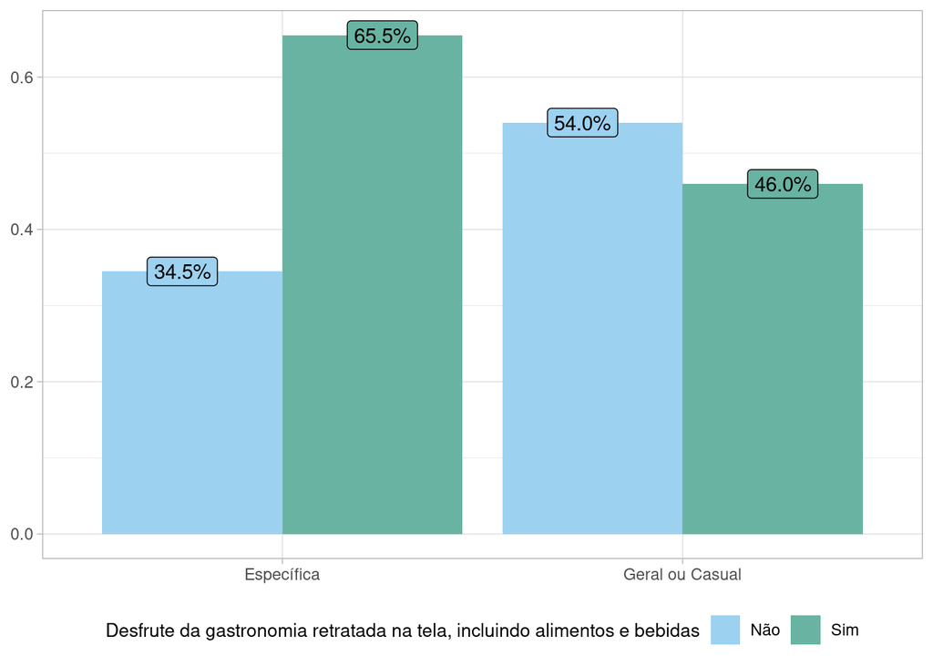

```
##
##  Pearson's Chi-squared test with Yates' continuity correction
##
## data:  data[, 1] and data[, 5]
## X-squared = 2.587, df = 1, p-value = 0.1077
```

### Gráfico 34: Turistas que realizaram a atividade Participação em eventos relacionados a filmes por grupo

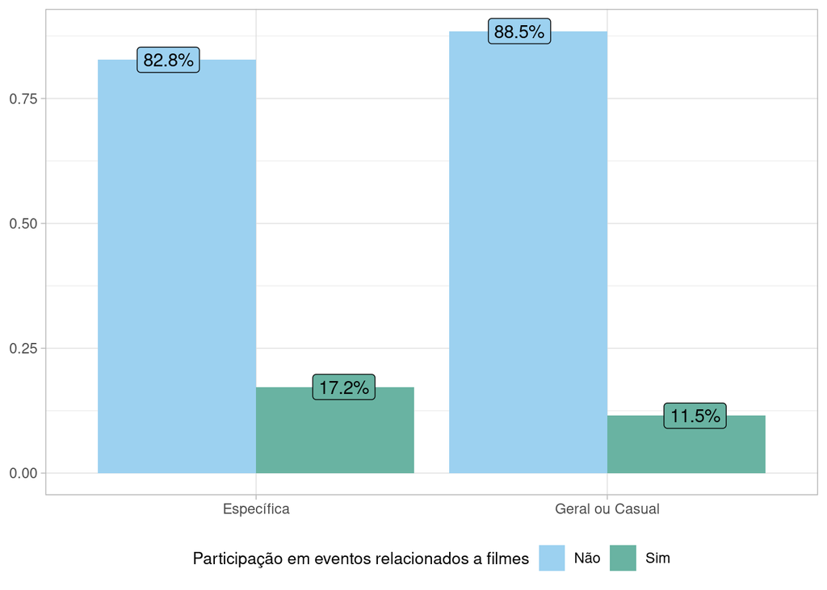

```
##
##  Pearson's Chi-squared test with Yates' continuity correction
##
## data:  data[, 1] and data[, 6]
## X-squared = 0.2297, df = 1, p-value = 0.6317
```

### Gráfico 35: Turistas que realizaram a atividade Visita a estabelecimentos exibidos na tela, como bares, restaurantes e outros por grupo

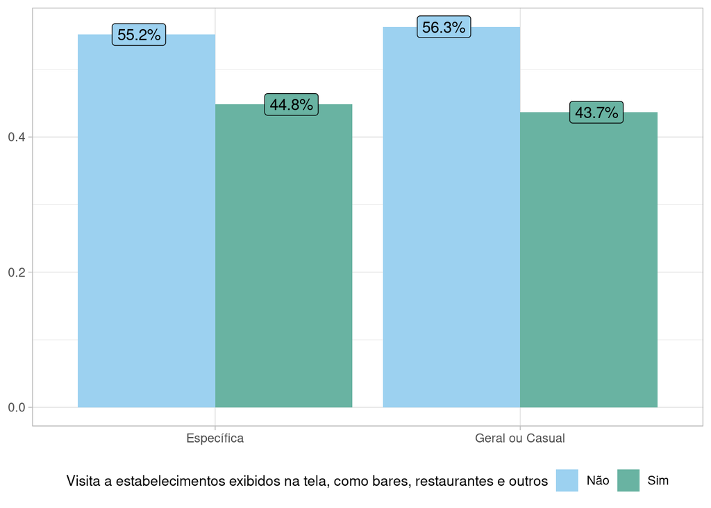

```
##
##  Pearson's Chi-squared test with Yates' continuity correction
##
## data:  data[, 1] and data[, 7]
## X-squared = 0, df = 1, p-value = 1
```

### Gráfico 36: Turistas que realizaram a atividade Realização de roteiros guiados em locais de filmagem por grupo

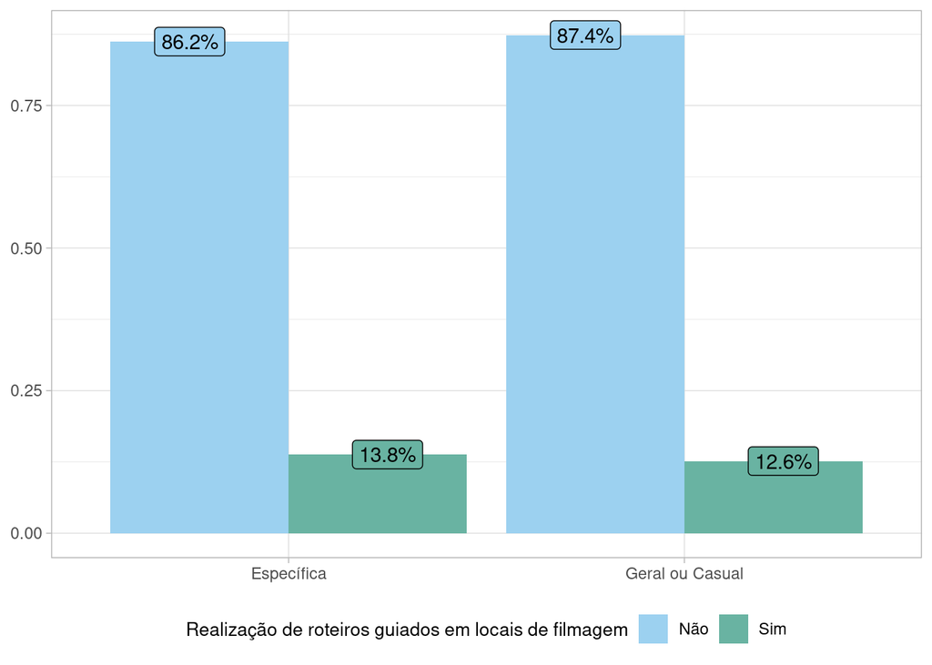

```
##
##  Pearson's Chi-squared test with Yates' continuity correction
##
## data:  data[, 1] and data[, 8]
## X-squared = 0, df = 1, p-value = 1
```

### Gráfico 37: Turistas que realizaram a atividade Outra atividade por grupo

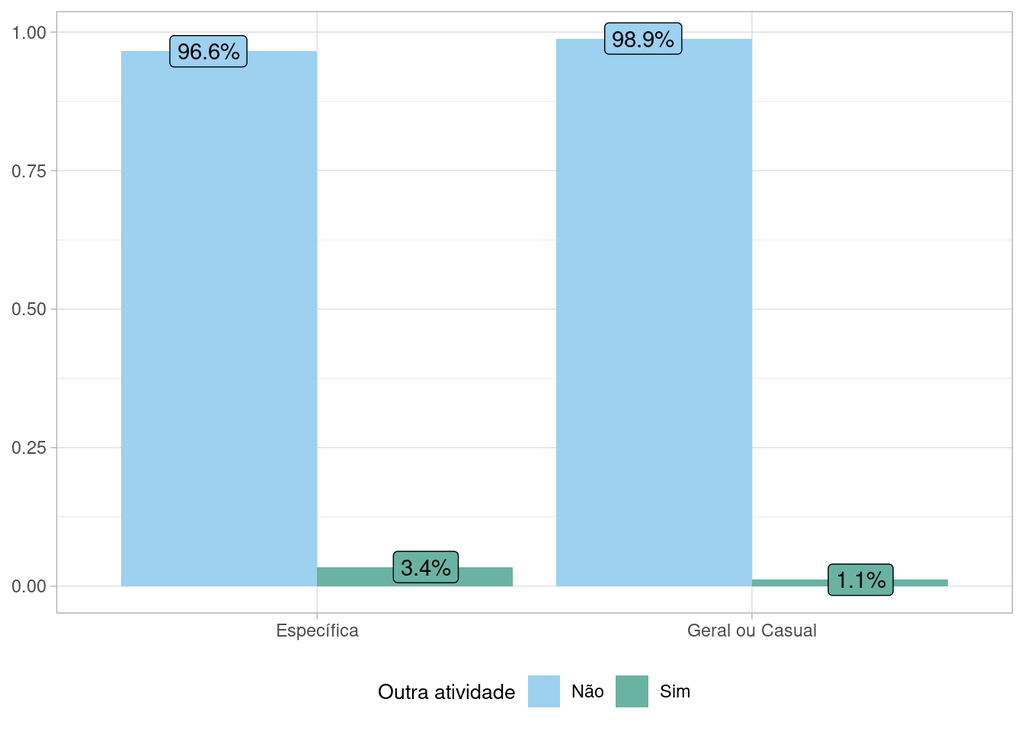

```
##
##  Pearson's Chi-squared test with Yates' continuity correction
##
## data:  data[, 1] and data[, 9]
## X-squared = 0, df = 1, p-value = 1
```

### Gráfico 38: Turistas que realizaram a atividade Visita a patrimônios culturais exibidos na tela por grupo

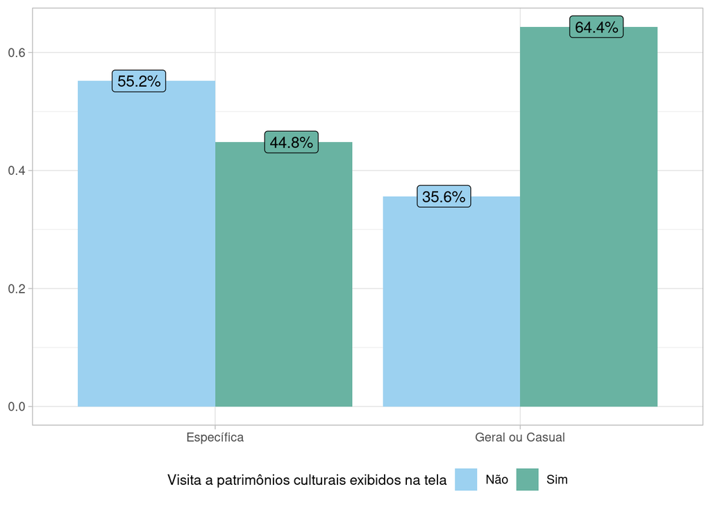

```
##
##  Pearson's Chi-squared test with Yates' continuity correction
##
## data:  data[, 1] and data[, 10]
## X-squared = 2.6827, df = 1, p-value = 0.1014
```

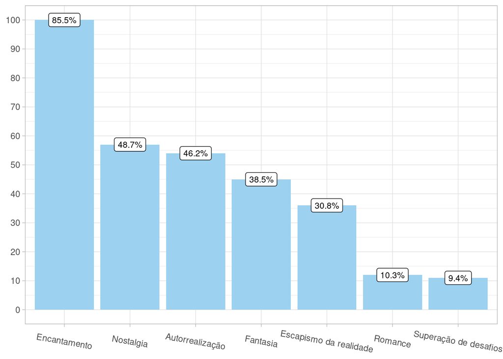

### Gráfico 40: Turistas que teve o sentimento nostalgia despertado durante a viagem por grupo

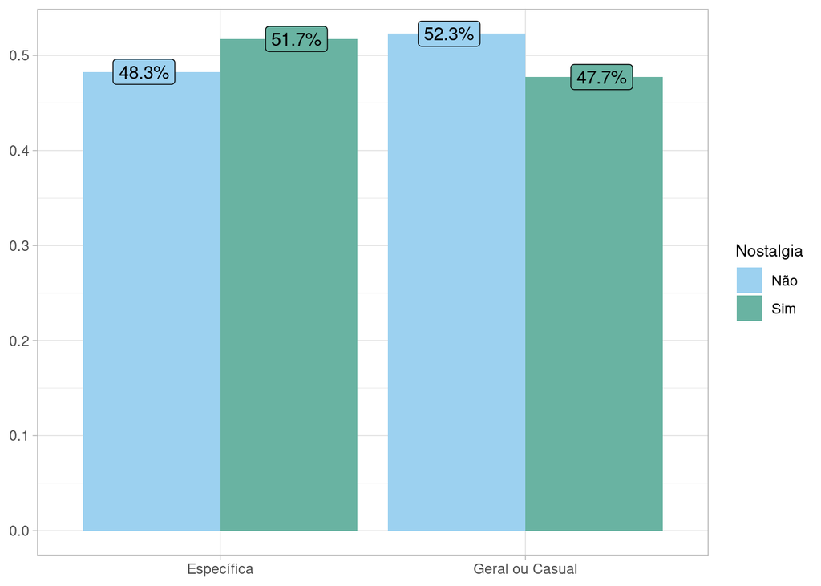

```
##
##  Pearson's Chi-squared test with Yates' continuity correction
##
## data:  data[, 1] and data[, 2]
## X-squared = 0.025366, df = 1, p-value = 0.8735
```

### Gráfico 41: Turistas que teve o sentimento autorrealização despertado durante a viagem por grupo

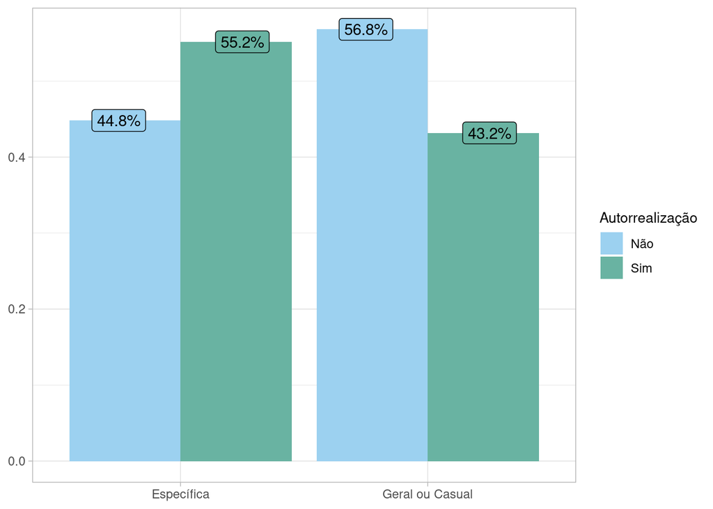

```
##
##  Pearson's Chi-squared test with Yates' continuity correction
##
## data:  data[, 1] and data[, 3]
## X-squared = 0.82551, df = 1, p-value = 0.3636
```

### Gráfico 42: Turistas que teve o sentimento escapismo da realidade despertado durante a viagem por grupo

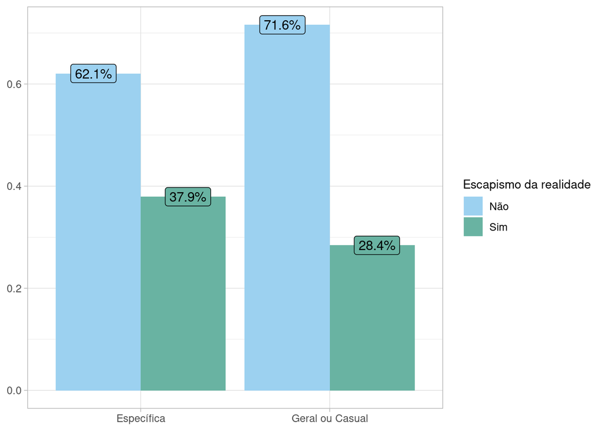

```
##
##  Pearson's Chi-squared test with Yates' continuity correction
##
## data:  data[, 1] and data[, 4]
## X-squared = 0.53519, df = 1, p-value = 0.4644
```

### Gráfico 43: Turistas que teve o sentimento fantasia despertado durante a viagem por grupo

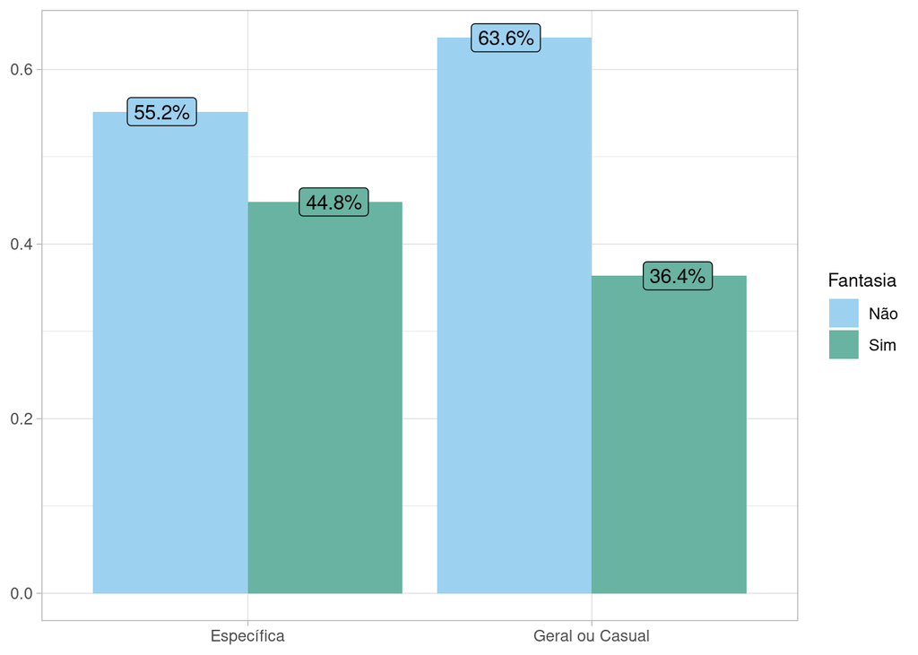

```
##
##  Pearson's Chi-squared test with Yates' continuity correction
##
## data:  data[, 1] and data[, 5]
## X-squared = 0.35101, df = 1, p-value = 0.5535
```

### Gráfico 44: Turistas que teve o sentimento encantamento despertado durante a viagem por grupo

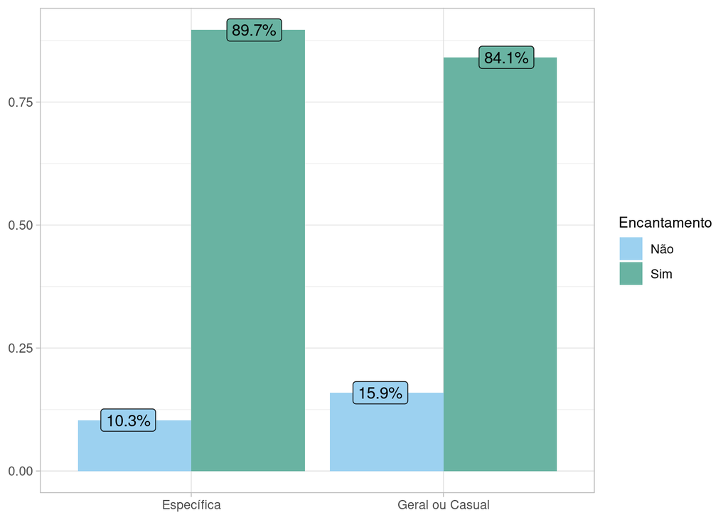

```
##
##  Pearson's Chi-squared test with Yates' continuity correction
##
## data:  data[, 1] and data[, 6]
## X-squared = 0.18803, df = 1, p-value = 0.6646
```

### Gráfico 45: Turistas que teve o sentimento romance despertado durante a viagem por grupo

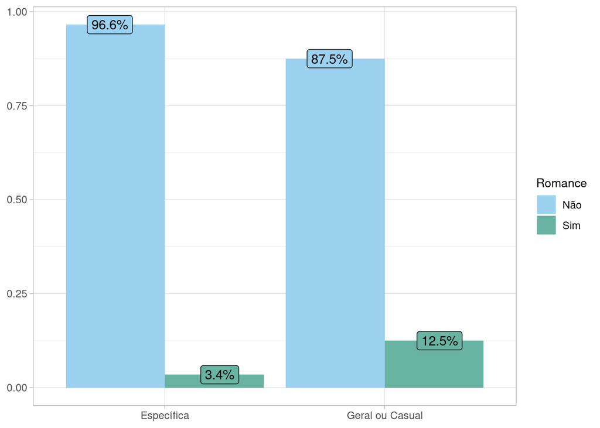

```
##
##  Pearson's Chi-squared test with Yates' continuity correction
##
## data:  data[, 1] and data[, 7]
## X-squared = 1.0827, df = 1, p-value = 0.2981
```

### Gráfico 46: Turistas que teve o sentimento supeação de desafios despertados durante a viagem por grupo

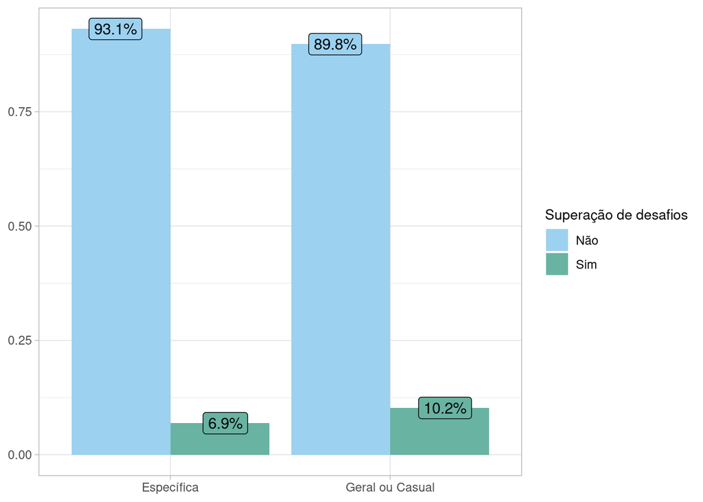

```
##
##  Pearson's Chi-squared test with Yates' continuity correction
##
## data:  data[, 1] and data[, 8]
## X-squared = 0.027612, df = 1, p-value = 0.868
```

### Gráfico 47: Turistas que teve o outros sentimentos despertados durante a viagem por grupo

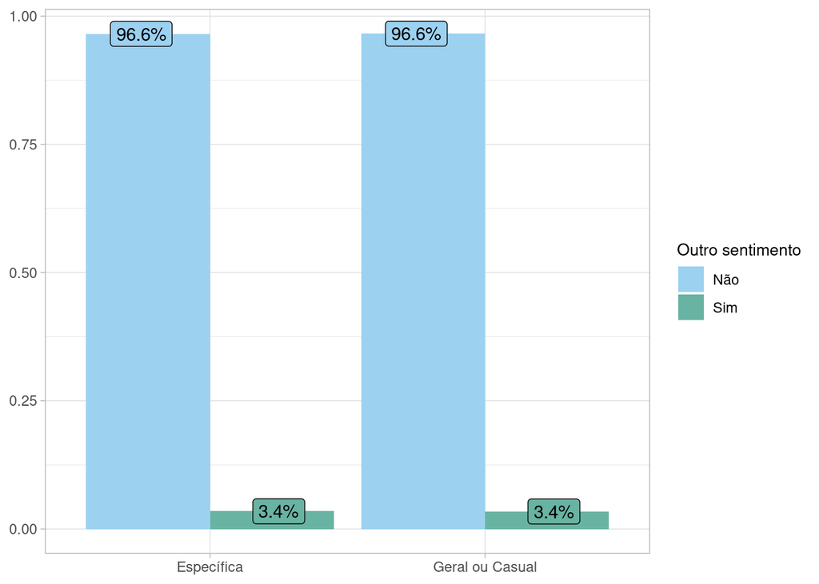

```
##
##  Pearson's Chi-squared test with Yates' continuity correction
##
## data:  data[, 1] and data[, 9]
## X-squared = 1.4851e-31, df = 1, p-value = 1
```

### Tabela 1 - Resumo estatística descritiva para cada variável

| Variável | Nível | Qtde | Percentual |
| --- | --- | --- | --- |
| Sexo | Feminino | 80 | 68.4% |
| Sexo | Masculino | 37 | 31.6% |
| Idade | Entre 18 - 30 | 47 | 40.2% |
| Idade | Entre 31 - 40 | 43 | 36.8% |
| Idade | Mais de 41 | 27 | 23.1% |
| Escolaridade | Ensino Médio | 87 | 74.4% |
| Escolaridade | Ensino Superior | 29 | 24.8% |
| Região residência | Centro - Oeste | 8 | 6.8% |
| Região residência | Nordeste | 16 | 13.7% |
| Região residência | Norte | 5 | 4.3% |
| Região residência | Resido no exterior | 9 | 7.7% |
| Região residência | Sudeste | 59 | 50.4% |
| Região residência | Sul | 20 | 17.1% |
| Frequência audiovisuais | Poucas vezes por semana | 34 | 29.1% |
| Frequência audiovisuais | Várias vezes por semana | 83 | 70.9% |
| Assinatura streaming | Não | 4 | 3.4% |
| Assinatura streaming | Sim | 112 | 95.7% |
| Grupo | Específica | 29 | 24.8% |
| Grupo | Geral ou Casual | 88 | 75.2% |
| Motivação | Conhecer lugares retratados nas telas, incluindo cenários, paisagens, clima, culturas, etc. | 99 | 84.6% |
| Motivação | Conhecer personagens (Celebridades). | 2 | 1.7% |
| Motivação | Obter mais informações sobre o filme: enredo, trama, gênero, etc. | 4 | 3.4% |
| Motivação | Outros | 10 | 8.5% |
| Percepção | Não | 1 | 0.9% |
| Percepção | Sim | 82 | 70.1% |
| Percepção | Parcialmente | 33 | 28.2% |
| Companhia | Outros | 5 | 4.3% |
| Companhia | Amigos | 31 | 26.5% |
| Companhia | Colegas de Trabalho | 1 | 0.9% |
| Companhia | Com companheiro/a (namorado/a, noivo/a, esposo/a) | 21 | 17.9% |

[output cut: 68 more lines]

**Teste qui-quadrado de independência**

Esse teste é utilizado para verificar se existe associação entre as variáveis grupo com cada uma das outras variáveis qualitativas.

Hipóteses:

$H_0$: As variáveis **grupo** com cada uma das outras variáveis são independentes

$H_1$: As variáveis **grupo** com cada uma das outras variáveis são independentes estão associadas

### Tabela 2 - Resumo teste qui-quadrado descritiva para cada variável

| Variável | p-valor |
| --- | --- |
| Visita a parques, praças e espaços na natureza exibidos na tela | 0.0033 |
| Filmes | 0.0086 |
| Satisfação | 0.092 |
| Visita a patrimônios culturais exibidos na tela | 0.1014 |
| Desfrute da gastronomia retratada na tela, incluindo alimentos e bebidas | 0.1077 |
| Idade | 0.1454 |
| Motivação | 0.2362 |
| Globoplay | 0.2695 |
| Star+ | 0.2845 |
| Romance | 0.2981 |
| Percepção | 0.307 |
| Visita a Parques temáticos baseados em atrações inspiradas em séries, filmes, etc | 0.3274 |
| Autorrealização | 0.3636 |
| Novelas | 0.4242 |
| Escolaridade | 0.4523 |
| Netflix | 0.4536 |
| Clipes de música | 0.4644 |
| Escapismo da realidade | 0.4644 |
| Companhia | 0.4781 |
| Fantasia | 0.5535 |
| Viki | 0.5576 |
| Disney+ | 0.6156 |
| Região residência | 0.6159 |
| Participação em eventos relacionados a filmes | 0.6317 |
| Frequência audiovisuais | 0.6619 |
| Encantamento | 0.6646 |
| Amazon Prime Vídeo | 0.6991 |
| Superação de desafios | 0.868 |
| Nostalgia | 0.8735 |
| Sexo | 0.8796 |
| Visita a cenários internos ou externos onde foram filmadas | 0.9107 |
| HBO Max | 0.9704 |
| Realizar outra viagem pelo audiovisual | 0.9771 |
| Assinatura streaming | 1 |
| Seriados | 1 |
| Outro audiovisual | 1 |
| Telecine | 1 |
| Outros streamig | 1 |
| Visita a estabelecimentos exibidos na tela, como bares, restaurantes e outros | 1 |
| Realização de roteiros guiados em locais de filmagem | 1 |
| Outra atividade | 1 |
| Outro sentimento | 1 |

## 3.2 - Modelo de regressão logística

A análise de regressão é uma ferramenta estatística que nos permite explorar as relações entre variáveis, identificar fatores significativos e quantificar o impacto desses fatores em uma variável de interesse. Como temos uma variável de interesse com duas categorias, vamos utilizar uma regressão logistica.

Essa abordagem permite a compreensão de forma mais intuitiva como as variáveis explicativas estão relacionadas à variável de interesse.

**Estimação do modelo de regrgessão logística**

Foram estimados dois modelos que todos os coeficientes deram significativos. Utilizamos os Testes de de independência para nortear quais variáveis seriam colocadas a princípio no modelo.

O modelo 1, como mostrado abaixo, a variável binária grupo é explicada pelas variáveis: - Visita a parques, praças e espaços na natureza exibidos na tela; - Filmes; - Satisfação; - Desfrute da gastronomia retratada na tela, incluindo alimentos e bebidas.

O modelo 2, como mostrado abaixo, a variável binária grupo é explicada pelas variáveis: - Visita a parques, praças e espaços na natureza exibidos na tela; - Filmes; - Desfrute da gastronomia retratada na tela, incluindo alimentos e bebidas.

É preciso saber se o modelo maior (modelo 1) é significativamente superior ao modelo menor (modelo 2), ou seja, se a varíavel “Satisfação” consegue melhorar na previsão de classificação do grupo. Caso a resposta seja não, optaremos pelo modelo 2 por ser mais parcimonioso.

Para isso, será preciso realizar a análise do que é chamado em Estatística de modelos encaixados, a partir da deviance dos modelos.

**Análise de modelos encaixados**

| Resid. Df | Resid. Dev | Df | Deviance | Pr(>Chi) |
| --- | --- | --- | --- | --- |
| 112 | 106.0773 | NA | NA | NA |
| 111 | 100.0668 | 1 | 6.010499 | 0.014221 |

A estatística $D_q$ (deviance do modelo com menos parâmetros) $D_p$ (deviance do modelo com mais parâmetros), onde q e p é número de parâmetros dos modelos, respectivamente, é útil como medida de variação dos dados explicada pelos termos que estão no modelo maior e não estão no modelo menor.

Assitoticamente, pode-se escrever:

$\Delta D$ = $D_q$ - $D_p$ ~ $\mathbf{X}^{2}_{p-q}$

Hipóteses:

$H_0$: a diferença entre os modelos não é significativa

$H_1$: a diferença entre os modelos é significativa

Como o valor-p deu 0.014, rejeitamos a hipótese nula e ficamos com o modelo com mais parâmetros. Acredita-se que a variável “Satisfação” contribui para explicar a variabilidade dos dados.

**Análise de deviance**

Agora, é preciso conferir se a deviance do modelo escolhido é moderada. Para decidir se uma deviance é pequena / moderada / grande, podemos usar como referência:

Se P(D > $\mathbf{X}^{2}_{n-p;\alpha}$) = $\alpha$; neste caso, 0 < D < $\mathbf{X}^{2}_{n-p;\alpha}$ indica deviance pequena ou moderada.

O valor esperado $\mathbf{X}^{2}_{n-p;\alpha}$ que é igual (n - p); neste caso, uma deviance moderada estaria próxima de n − p.

Para o modelo, D = 100.07. A média da distribuição $\mathbf{X}^{2}_{12}$ é 112. D está próximo da média, logo podemos considerá-la moderada. Também, o percentil da distribuição $\mathbf{X}^{2}_{112}$ com $\alpha$ = 0.05 é 137.70. Como 0 < D < 137.7015, o modelo possui deviance moderada.

### Tabela 4 - Regressores, coeficientes, Valor-p e impacto da covariável sobre a odds

|  | Coeficiente | Valor-p | 100*(exp{beta}-1) |
| --- | --- | --- | --- |
| Intercepto | 1.158200 | 0.2005 | 218.41966 |
| Filmes_Sim | -2.084936 | 0.0005 | -87.56849 |
| Visita a parques, praças e espaços na natureza exibidos na tela_Sim | -2.766893 | 0.0032 | -93.71430 |
| Muito Satisfeito | 1.356181 | 0.0228 | 288.13435 |
| Desfrute da gastronomia retratada na tela_Sim | 1.365575 | 0.0185 | 291.79748 |

**Análise de resíduos**

### Gráfico 48 - Distância de Cook

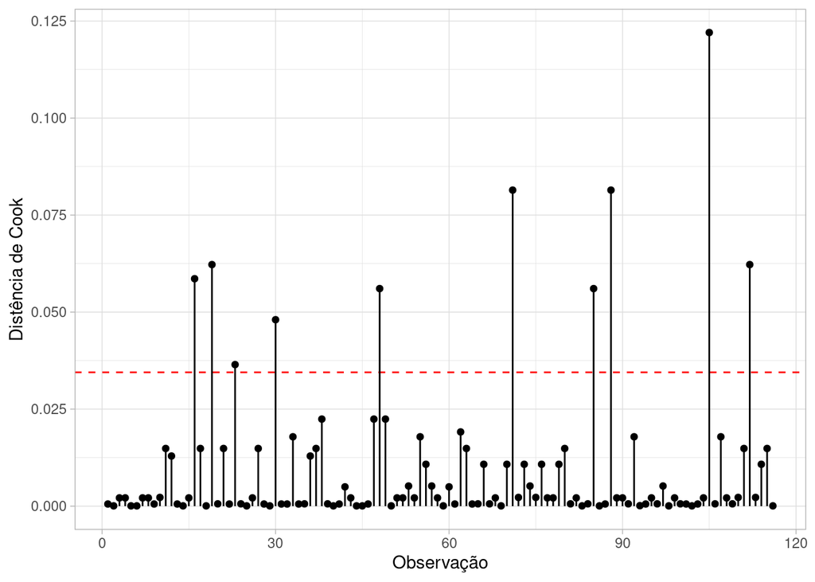

### Tabela 5 - Regressores, coeficientes, Valor-p e impacto da covariável sobre a odds

|  | Coeficiente | Valor-p | 100*(exp{beta}-1) |
| --- | --- | --- | --- |
| Intercepto | 0.6262247 | 0.4958 | 87.05354 |
| Filmes_Sim | -2.2581642 | 0.0003 | -89.54578 |
| Visita a parques, praças e espaços na natureza exibidos na tela_Sim | -2.3150870 | 0.0132 | -90.12424 |
| Satisfeito/ Indiferente/ Muito insatisfeito | 1.4400722 | 0.0178 | 322.10004 |
| Desfrute da gastronomia retratada na tela_Sim | 1.5610513 | 0.0114 | 376.38269 |

### Gráfico 49: Resíduos contra os valores ajustados do modelo

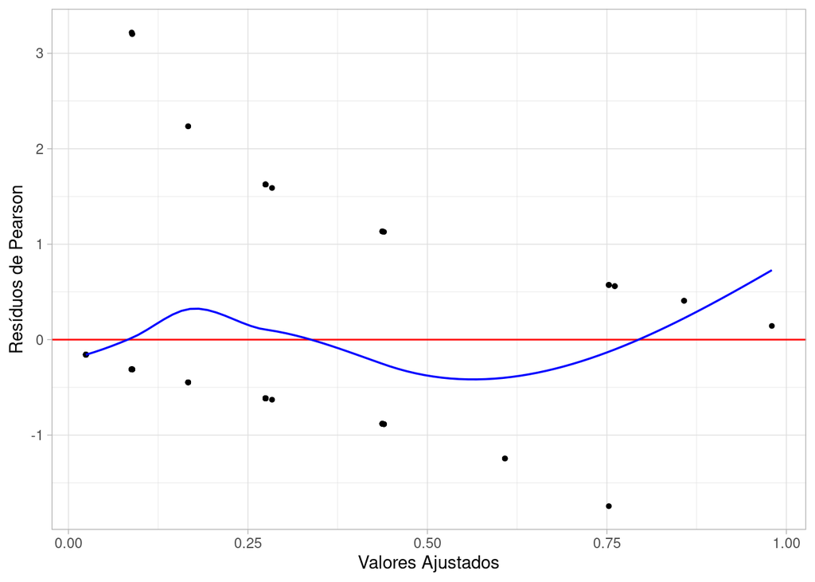

A curva Lowess mostra proximidade ao patamar 0. Contudo, ela apresenta formato de parábola, o que indica a necessidade de ajustar o MLG logístico com efeito quadrático de alguma covariáavel. Contudo, como as variáveis são todas binárias, essa transformação não teria efeito. Assim, o modelo possível obtido é este.

Por, abaixo o gráfico evidencia a probalidade de um indvpiduo ser classificado como pertencente ao grupo “específico”, conforme o modelo prevê.

### Gráfico 50: Probabilidade do turista ser classificado como “Específico” pelo modelo

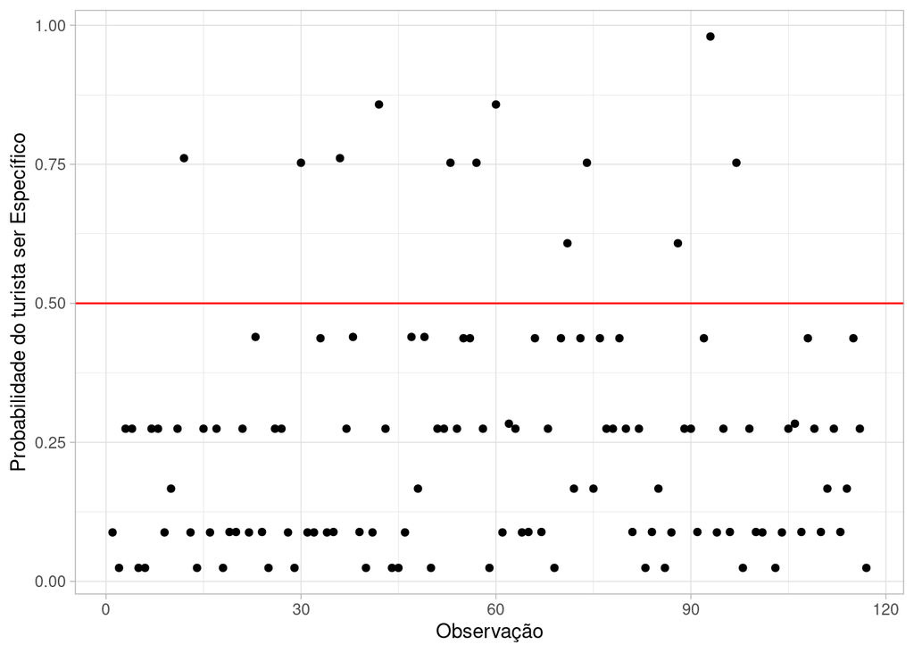

# 4. Conclusão

A análise descritiva e estatística dos dados revelou, as variáveis mais influentes no contexto da motivação de turistas por produções audiovisuais. Destacaram-se, entre elas, as perguntas relacionadas às *atividades de lazer durante a viagem*, *preferências em produções audiovisuais* e o *nível de satisfação com a experiência audiovisual-induzida*. Esses insights forneceram uma compreensão mais profunda das dinâmicas envolvidas e também direcionaram a construção do modelo final de regressão logística. Ao apresentar esse modelo, buscamos não apenas descrever, mas também prever a propensão de um indivíduo integrar o grupo de turistas motivados pelo audiovisual, fazendo assim para uma abordagem extensiva e preditiva nas pesquisas sobre o tema.